# Session 6: The Recommendation Problem

> *"The basic idea of recommender systems is to utilize these various sources of data to infer customer interests."* — Aggarwal, *Recommender Systems: The Textbook* (2016)

## What does recommendation look like in the real world?

- **Netflix**: ~80 % of watched content comes from recommendations
- **Amazon**: ~35 % of revenue attributed to recommendations
- **YouTube**: ~70 % of watch time from recommendations

Recommendation **is** the product.

*Sources: Netflix — Gomez-Uribe & Hunt, *ACM TMIS* (2015); Amazon — McKinsey (2013); YouTube — Solsman, *CNET* (2018).*

## A bit of formalism

The same idea in symbols — these are the variables you'll meet in every recommender-systems paper or textbook (Aggarwal 2016, Falk 2018):

- $U = \{u_1, u_2, \dots, u_n\}$ — set of $n$ **users**
- $I = \{i_1, i_2, \dots, i_m\}$ — set of $m$ **items**
- $R \in \mathbb{R}^{n \times m}$ — the **rating matrix**, where $r_{u,i}$ is the rating user $u$ gave item $i$ (or $\texttt{NaN}$ if missing)

A recommender system solves one of two tasks:

| Task | What | As a function |
| --- | --- | --- |
| **Rating prediction** | Fill in the missing $r_{u,i}$ | $p : U \times I \to \mathbb{R}$ (regression) or $p : U \times I \to C$ (classification) |
| **Ranking prediction** | For user $u$, return the top-$k$ items they'll like most | $\text{top-}k : U \to I^k$ |

Ranking can be *reduced to* rating prediction — predict every score, then sort — but it's often optimized directly, and a low rating-prediction error (RMSE) does **not** guarantee a good ranking.

## The Rating Matrix

Every recommender system is built on a **rating matrix**: rows = users, columns = items, values = ratings (mostly missing).

### MovieLens (small) at a glance

The concrete dataset behind every plot in this lecture.

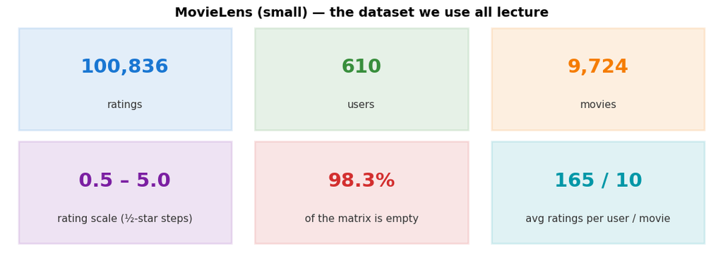

### A small corner — what real ratings look like

Twelve users × twelve movies. Coloured cells are actual star ratings (0.5 – 5). White cells are missing — nobody rated those.

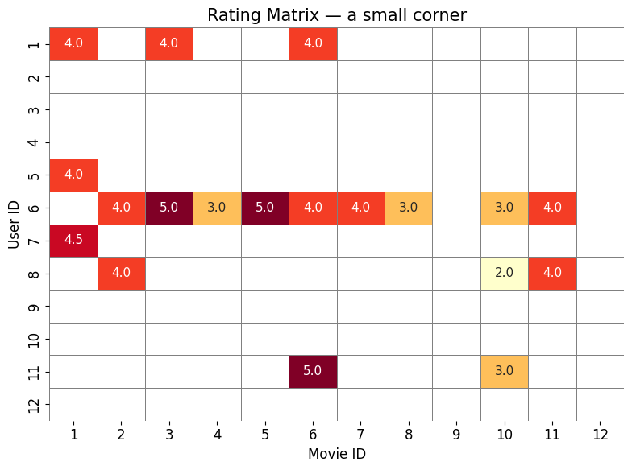

### Zooming out — where do we have ratings *at all*?

Now 80 users × 200 movies. Each black dot is a rating that exists; white is missing. **Most of the space is empty** — that's the core challenge of recommendation.

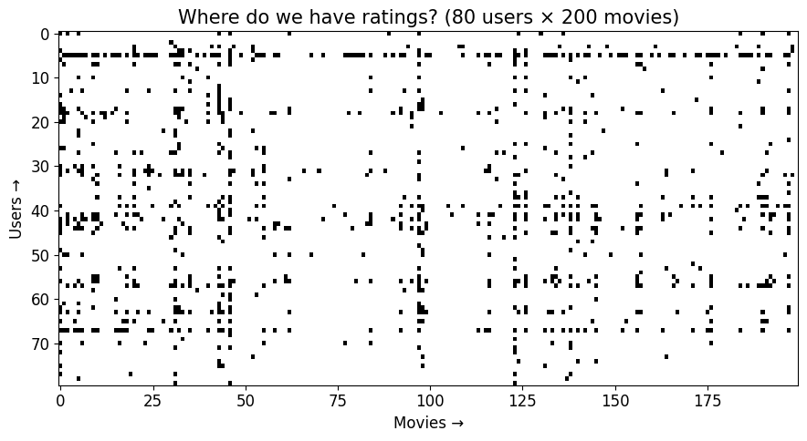

## Types of Feedback

Ratings aren't the only signal. Users leave traces in many forms — each shapes how the matrix is built.

### Explicit feedback — star ratings

The user gives an explicit numeric score — the cleanest signal, but expensive to collect (most users never rate). And the scores that *do* arrive are **skewed high**: people mostly rate things they already liked (a selection bias).

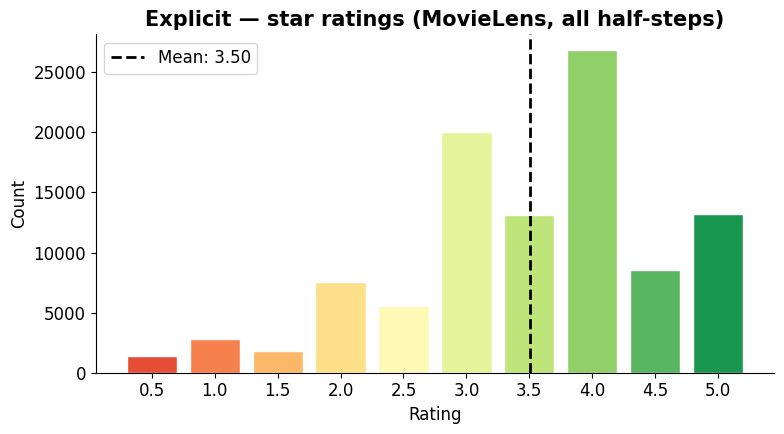

### Implicit feedback — clicks, time spent, page views

The user never explicitly rates anything — we infer interest from behaviour. Much more abundant, but noisier (a click isn't a "like").

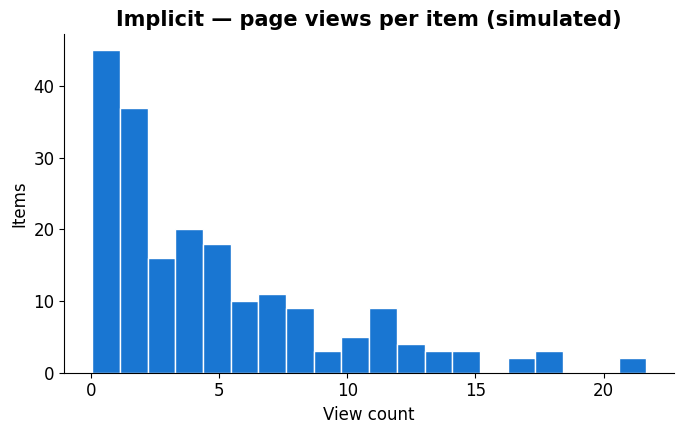

### Binary feedback — like / dislike

Thumbs up or down only. Throws away rating *magnitude* but is much easier for users — and matches how YouTube and Spotify now work.

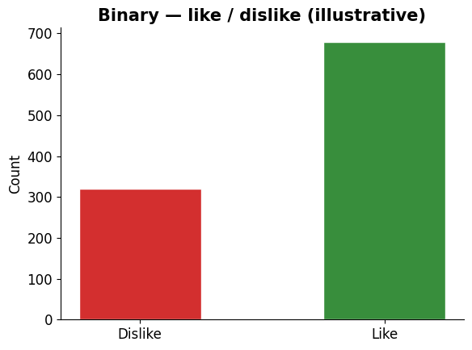

### Ordinal feedback — categories with order

Bad / neutral / good — fewer levels than stars, more nuance than binary. Common in surveys and quick UI polls.

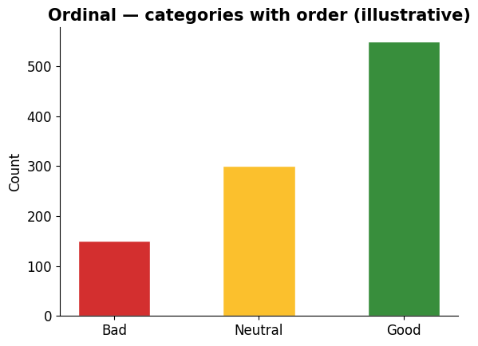

## Different Data Modalities

Recommendations involve more than numbers. We work with **text**, **images**, and **tabular** data — each needs a different strategy to become a computable vector.

### Text data — e.g. review word frequencies

Words become numbers via word counts, TF-IDF, or (later in the course) sentence-embedding vectors.

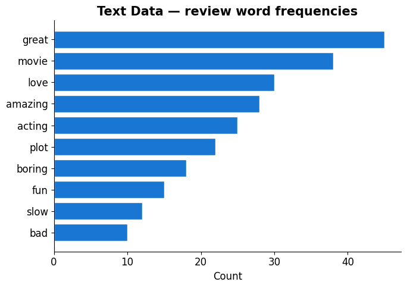

### Image data — e.g. a painting → pixel values

An image is a **3-D array**: **height × width × 3 colour channels** (red, green, blue). Every pixel stores 3 numbers — the painting below is a $760 \times 960 \times 3$ grid of values.

*Isn't there a saturation/brightness channel?* Not in RGB. Saturation and brightness are the axes of a **different** 3-channel encoding, **HSV** (Hue, **S**aturation, **V**alue = brightness) — the same image, just re-encoded. Images can also carry a 4th **alpha** (transparency) channel → RGBA.

[figure not shown]

### Tabular / ordinal data — e.g. genre scores per item

Hand-crafted attribute vectors. The most direct form — every column is already a number.

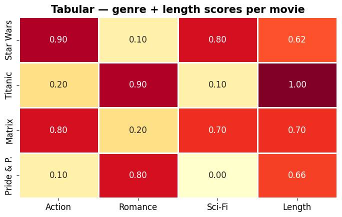

Each modality needs its own strategy to turn into a vector.

## Problem 1: Sparsity

We just saw the matrix looks mostly empty — now let's put a number on it. How much of the MovieLens rating matrix is actually filled?

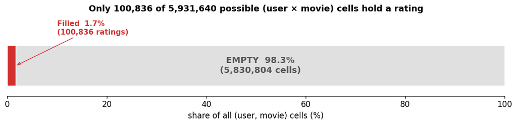

```
→ 98.3% of the matrix is empty. Standard ML methods can't handle this directly.
```

## Problem 2: The Long Tail

A handful of popular items get most of the ratings. The vast majority — the "long tail" — get very few.

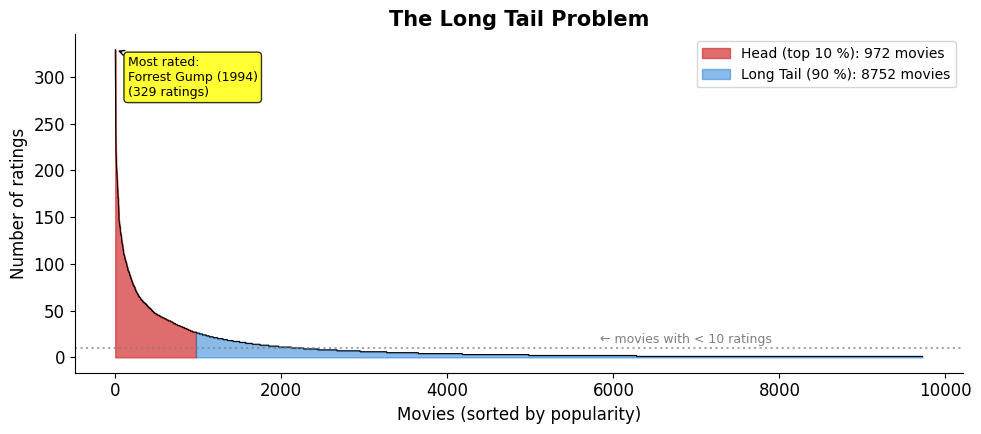

```
→ 7455 of 9724 movies (77%) have < 10 ratings.
```

## Problem 3: Cold Start

What happens when a *user* or an *item* is brand new — no rating history at all?

### What cold start looks like in the matrix

A brand-new **user** is an empty *row*; a brand-new **item** is an empty *column*. There is nothing to learn from.

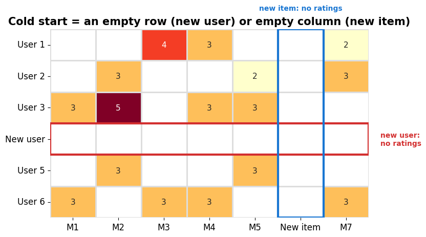

### Cold-start users? Not in *this* dataset

MovieLens-small only keeps users who have rated **at least 20 movies**, so it has **no** cold-start users by construction. Real systems aren't so lucky — we'll simulate a brand-new user in the CF example later.

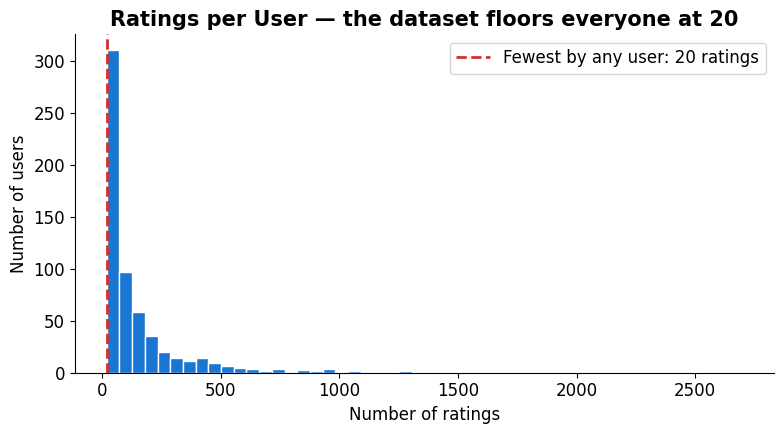

```
→ Minimum ratings by any user: 20. MovieLens filters cold-start users out.
```

### Cold-start items — these are real

Movies have no such floor: the least-rated have a single rating. **62 % of movies have fewer than 5 ratings** — far too few to learn from.

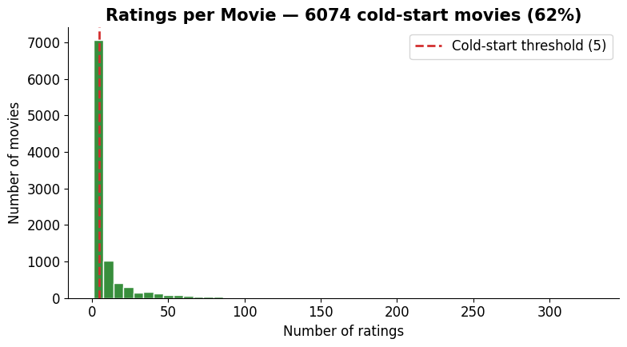

```
→ New users and rarely-rated movies: not enough data to make good predictions.
```

## The Netflix Prize — a $1M bounty on these problems

Sparsity, long tail, cold start — a real, costly problem. In **October 2006** Netflix turned it into the most famous ML competition in history.

| **Prize** | **$1,000,000** |
| --- | --- |
| Data | **100M ratings** · **480k users × 18k movies** |
| Sparsity | **~98.8 %** empty |
| Goal | beat *Cinematch* by **≥ 10 %** RMSE |
| Ran | **2006 – 2009** |

### Winner: *BellKor's Pragmatic Chaos*

Combined in layers (*"stacking"*). **Matrix factorization did the heavy lifting.**

### The photo finish (2009)

Two scores, two stories — and the held-out **test set**, not the public leaderboard, is what paid out:

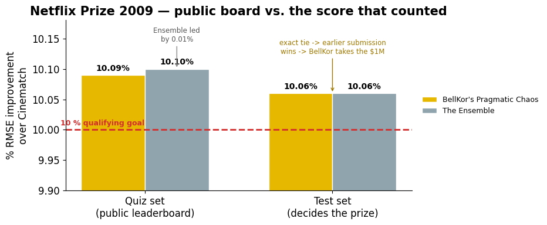

## A First Attempt: Collaborative Filtering

Before we look at our roadmap, let's see what people tried **directly on the rating matrix**: **Collaborative Filtering (CF)**.

- **User-based CF:** *"Users who rated similarly to you also liked X"* — find your rating-twins, borrow their opinions
- **Item-based CF:** *"Movies that got similar ratings tend to be similar"* — if people who liked A also liked B, recommend B

This powered early Amazon and Netflix.

We'll work through **user-based CF** below; item-based is the same idea with the matrix transposed.

### A tiny example — can we predict the "?"

Four users, five movies. **You** haven't rated "Saw". Alice and Bob have similar taste to you; Carol's is opposite. What rating would you give?

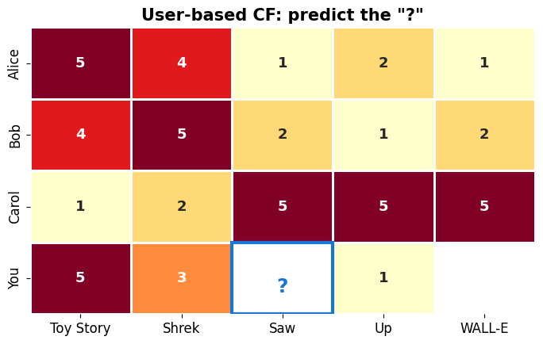

### Collaborative filtering in three steps

CF works directly on the rating matrix $R$ — no movie features needed:

1. *(offline)* **Compute similarity** for every user pair → fill the **user–user matrix** $\hat{U}$ (users × users), where $\hat{U}_{u,v} = \text{sim}(u, v)$.
2. *(online)* **Find neighbours:** take the target user's $k$ most similar users.
3. *(online)* **Predict** the missing rating from what those neighbours rated.

The whole game is **Step 1**: how do we define $\text{sim}(u, v)$?

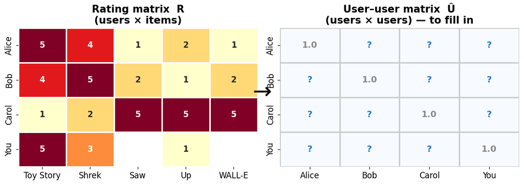

### Measuring similarity — attempt 1: dot product

Treat each user's ratings as a vector $r_u$ and take the **dot product**:

$$\text{sim}(u, v) = \langle r_u, r_v \rangle = \sum_i r_{u,i}\, r_{v,i}$$

❌ **Problem:** the matrix is mostly empty — for almost any pair, most items are rated by only one of them (or neither), so most products involve a missing value. The plain dot product isn't even well-defined.

### Fix 1 — only the items both users rated

Restrict the sum to the **common itemset** $I_{uv} = I_u \cap I_v$ (items *both* rated):

$$\text{sim}(u, v) = \sum_{i \in I_{uv}} r_{u,i}\, r_{v,i}$$

❌ **Problem: user bias.** A generous rater who gives everything 4–5 ★ looks similar to *everyone*. We're comparing rating *levels*, not *taste*.

### Fix 2 — subtract each user's average (de-bias)

Center each user on their own mean $\mu_u$, so we compare *deviations* from what is normal **for them**:

$$\text{sim}(u, v) = \sum_{i \in I_{uv}} (r_{u,i} - \mu_u)(r_{v,i} - \mu_v)$$

Now a grump and an enthusiast with the *same taste* line up. ❌ **Last problem:** the sum still grows with **scale** — the more items the two *co-rate*, or the more *extremely* they rate, the bigger it gets, regardless of how well they actually agree.

### Fix 3 — normalise → this *is* Pearson correlation

$$\text{sim}(u, v) = \frac{\langle r_u - \mu_u,\; r_v - \mu_v \rangle}{\lVert r_u - \mu_u \rVert \, \lVert r_v - \mu_v \rVert}$$

**Why divide by the lengths?** The raw sum on top isn't comparable between pairs: it gets bigger when the two users **co-rate more items** (more terms in the sum) or simply rate **more extremely** — neither of which means they actually agree *more*. Dividing by both vector lengths cancels that scale, putting every pair on the same $[-1, 1]$ footing — so we compare the **shape** of their agreement, not its size.

That's exactly the **cosine of the angle** between the two rating vectors — i.e. **Pearson correlation**: $+1$ identical taste, $0$ unrelated, $-1$ opposite.

### Step 1: Pearson's correlation coefficient

Written out over the common items $I_{uv}$:

$$ \text{sim}(u, v) \;=\; \frac{\displaystyle\sum_{i \in I_{uv}} (r_{u,i} - \mu_u)\,(r_{v,i} - \mu_v)}{\sqrt{\displaystyle\sum_{i \in I_{uv}} (r_{u,i} - \mu_u)^2}\;\sqrt{\displaystyle\sum_{i \in I_{uv}} (r_{v,i} - \mu_v)^2}} $$

It's the statistician's $\rho_{X,Y} = \dfrac{\operatorname{cov}(X,Y)}{\sigma_X\,\sigma_Y}$ on the two users' co-rated ratings. **Intuition:** when you rate a film above *your* average, does $v$ tend to be above *theirs* too? Consistent agreement → near $+1$. Do this for every pair → the matrix $\hat{U}$.

### Step 2: find the top-$k$ nearest neighbours

With $\hat{U}$ filled in, the **peer group** $N_k(u)$ is just user $u$'s $k$ most similar users — k-nearest-neighbours on the similarity matrix.

| $\hat{U}$ | Alice | Bob | Carol |
| --- | --- | --- | --- |
| **You** | $+0.98$ | $+0.72$ | $-0.96$ |

For *You*, the nearest neighbours are **Alice and Bob**. (Our example is tiny, so we keep all three as the peer group — Carol's negative similarity simply pulls the estimate *down*.)

### Step 3: predict — a similarity-weighted average

First bundle the normaliser into **one weight per neighbour**, scaled by the total similarity so the weights' **magnitudes sum to 1**:

$$w_{u,v} \;=\; \frac{\text{sim}(u, v)}{\displaystyle\sum_{v' \in N_k(u)} |\text{sim}(u, v')|}$$

Now the prediction is just **your baseline + a weighted average of the neighbours' de-biased opinions**:

$$\hat{r}_{u,i} \;=\; \mu_u \;+\; \sum_{v \in N_k(u)} w_{u,v}\,(r_{v,i} - \mu_v)$$

A similar neighbour gets a large $w_{u,v}$; an *opposite*-taste one gets a **negative** weight that flips their vote. The term $r_{v,i} - \mu_v$ is $v$'s opinion of $i$ relative to *their* own average.

### Worked example — similarity of *You* to each user

Apply Pearson to our 4-user example. Alice and Bob come out **positive** (same taste); Carol **negative** (opposite taste).

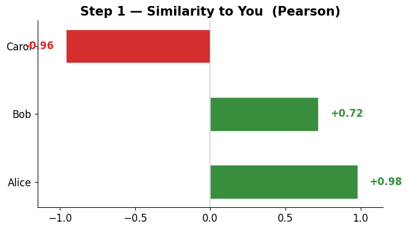

### Worked example — the neighbours' ratings for *Saw*

Alice and Bob (positive similarity) rated it **low**. Carol (negative similarity) rated it **high** — but her *negative* weight flips that into downward pressure.

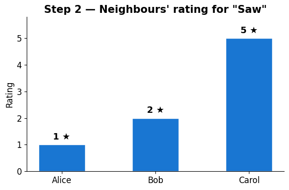

### Worked example — the predicted rating

Plug the similarities and ratings into the formula. Result: **You probably won't like horror**, because your rating-twins didn't.

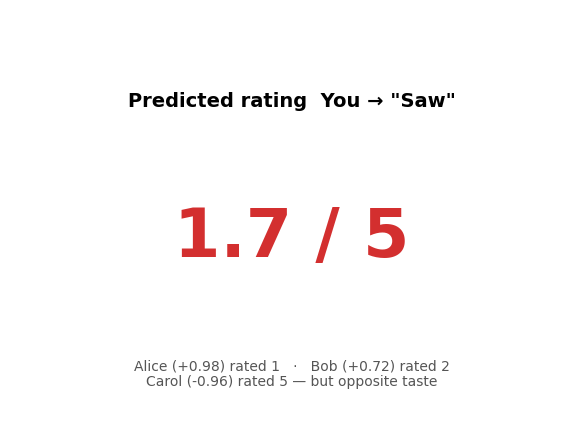

```
→ Prediction: 1.7/5
```

### But what about cold start?

CF needs **overlapping ratings** between users. What happens when a user is new?

### Two new users join — Dave and Eve

Dave has rated just one movie. Eve hasn't rated anything yet. The red dashed box shows the "cold start" rows.

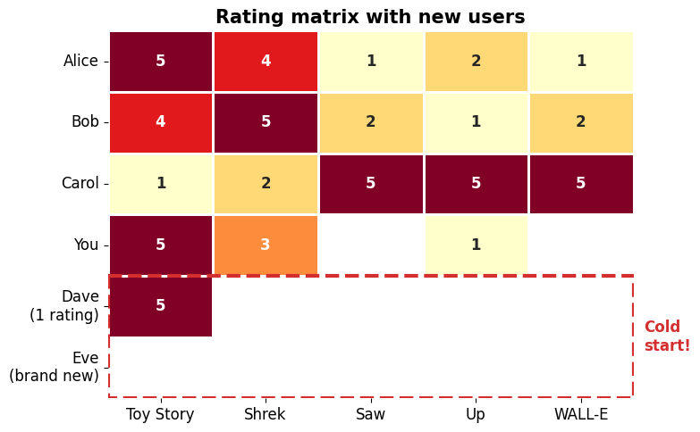

### Can CF still find neighbours?

Pearson correlation needs at least 2 co-rated items. Dave has just 1; Eve has 0. **CF is completely blind** for them.

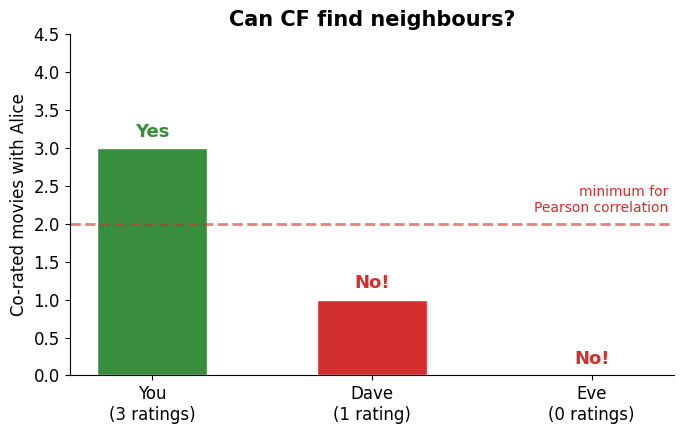

```
→ Dave: 1 rating → cannot compute similarity.
  Eve: 0 ratings → CF is completely blind.
```

Cold start is one of the reasons we'll move beyond the rating matrix in the coming lectures — from hand-crafted feature vectors (L7) to learned latent factors (L8) to neural embeddings (L9–10).

## The Roadmap

From sparse matrix → vectors → learned embeddings → cluster-scale retrieval.

[figure not shown]

## Key Takeaways

1. Recommendation = predicting missing entries in a **very sparse** matrix
2. Data comes in many forms: ratings, text, images, clicks
3. Core challenges: **sparsity**, **long tail**, **cold start**
4. **Collaborative Filtering** uses rating patterns to find similar users — elegant, but breaks on cold start
5. **Path forward:** represent items as **vectors** in a feature space, so we can recommend even without rating overlap → next lecture